# analyzing_titanic_data

[figure not shown]

### Uma breve introdução sobre o Titanic:

O **RMS Titanic** foi um navio de passageiros britânico operado pela White Star Line e construído pelos estaleiros da Harland and Wolff em Belfast. Foi a segunda embarcação da Classe Olympic de transatlânticos depois do RMS Olympic e seguido pelo HMHS Britannic. Projetado pelos engenheiros navais Alexander Carlisle e Thomas Andrews, sua construção começou em março de 1909 e ele foi lançado ao mar em maio de 1911. O Titanic foi pensado para ser o navio mais luxuoso e mais seguro de sua época, gerando lendas que era supostamente **"inafundável"**.

### Qual é o objetivo desse estudo?

Aqui iremos analisar dados dos passageiros do Titanic, como *idade, assento, sexo, classe, etc* para tentar descobrirmos motivos pelos quais os que sobreviveram, sobreviveram. Iremos aqui tentar fazer correlações também, como por exemplo *Será que a classe alterou significativamente a chance da pessoa sobreviver?*, *Será que a idade também foi um fator importante nisso?*,*Será que ter parentes influenciou na sobrevivência, no sentido de um "projeter" o outro?*, *Será que o setor que o tripulante estava colaborou com isso?*, etc.

Inicialmente iremos realizar uma limpeza nos dados, pois eles não estão padronizados. Após isso virão as análises e visualizações, fechando com a conlusão :-)

Nosso índice é o seguinte:

#### 1- Limpando os dados

#### 2- Realizando as análises

#### 3- Visualizando as análises

#### 4- Conclusão

```python
## fazendo com que eu possa importar bibliotecas
import sys

sys.path.append('/nanodegree/anaconda2/lib/python2.7/site-packages')
```

### Aqui está uma legenda dos campos que iremos analisar

```
VARIABLE DESCRIPTIONS:
survival        Survival
                (0 = No; 1 = Yes)
pclass          Passenger Class
                (1 = 1st; 2 = 2nd; 3 = 3rd)
name            Name
sex             Sex
age             Age
sibsp           Number of Siblings/Spouses Aboard
parch           Number of Parents/Children Aboard
ticket          Ticket Number
fare            Passenger Fare
cabin           Cabin
embarked        Port of Embarkation
                (C = Cherbourg; Q = Queenstown; S = Southampton)

SPECIAL NOTES:
Pclass is a proxy for socio-economic status (SES)
 1st ~ Upper; 2nd ~ Middle; 3rd ~ Lower

Age is in Years; Fractional if Age less than One (1)
 If the Age is Estimated, it is in the form xx.5

With respect to the family relation variables (i.e. sibsp and parch)
some relations were ignored.  The following are the definitions used
for sibsp and parch.

Sibling:  Brother, Sister, Stepbrother, or Stepsister of Passenger Aboard Titanic
Spouse:   Husband or Wife of Passenger Aboard Titanic (Mistresses and Fiances Ignored)
Parent:   Mother or Father of Passenger Aboard Titanic
Child:    Son, Daughter, Stepson, or Stepdaughter of Passenger Aboard Titanic

Other family relatives excluded from this study include cousins,
nephews/nieces, aunts/uncles, and in-laws.  Some children travelled
only with a nanny, therefore parch=0 for them.  As well, some
travelled with very close friends or neighbors in a village, however,
the definitions do not support such relations.
```

## Importando as bibliotecas

```python
%matplotlib inline
import pandas as pd # Para criarmos DataFrames
import numpy as np # Realizar alguns calculos matemáticos
import matplotlib.pyplot as plt # Para criação de gráficos
import seaborn as sns # Design de gráficos mais atraentes
import re # Para utilizar Regex
from collections import Counter
```

Bom, agora que já importamos as bibliotecas que iremos utilizar para realizar a análise, vamos ler o arquivo e armazená-lo em um dataframe do Pandas.

```python
## primeiro vamos ler o nosso arquivo
titanic_data = pd.read_csv('titanic_data.csv', encoding='ISO-8859-1')
```

```python
## visualizando as primeiras linhas
titanic_data.head()
```

|  | PassengerId | Survived | Pclass | Name | Sex | Age | SibSp | Parch | Ticket | Fare | Cabin | Embarked |
| --- | --- | --- | --- | --- | --- | --- | --- | --- | --- | --- | --- | --- |
| 0 | 1 | 0 | 3 | Braund, Mr. Owen Harris | male | 22 | 1 | 0 | A/5 21171 | 7.2500 | NaN | S |
| 1 | 2 | 1 | 1 | Cumings, Mrs. John Bradley (Florence Briggs Th... | female | 38 | 1 | 0 | PC 17599 | 71.2833 | C85 | C |
| 2 | 3 | 1 | 3 | Heikkinen, Miss. Laina | female | 26 | 0 | 0 | STON/O2. 3101282 | 7.9250 | NaN | S |
| 3 | 4 | 1 | 1 | Futrelle, Mrs. Jacques Heath (Lily May Peel) | female | 35 | 1 | 0 | 113803 | 53.1000 | C123 | S |
| 4 | 5 | 0 | 3 | Allen, Mr. William Henry | male | 35 | 0 | 0 | 373450 | 8.0500 | NaN | S |

# 1- Limpando os dados

Vamos arrumar também os nomes, apenas para ficar mais fácil de lermos. Irei criar duas novas colunas, chamadas *FirstName* e *LastName* :)

Irei criar duas funções, uma para o *sobrenome* (last_name) e outra para o *primeiro nome* (first_name). Irei aplicá-las ao DataFrame utilizando o método *apply*, que já executa a função para todos os registros do meu DataFrame, sem que eu precise criar um loop por fora :)

```python
def first_name(input):
        return input.split(',')[1]

def last_name(input):
    return input.split(',')[0]
```

```python
titanic_data['FirstName'] = titanic_data['Name'].apply(first_name)
titanic_data['LastName'] = titanic_data['Name'].apply(last_name)
```

```python
titanic_data.head()
```

|  | PassengerId | Survived | Pclass | Name | Sex | Age | SibSp | Parch | Ticket | Fare | Cabin | Embarked | FirstName | LastName |
| --- | --- | --- | --- | --- | --- | --- | --- | --- | --- | --- | --- | --- | --- | --- |
| 0 | 1 | 0 | 3 | Braund, Mr. Owen Harris | male | 22 | 1 | 0 | A/5 21171 | 7.2500 | NaN | S | Mr. Owen Harris | Braund |
| 1 | 2 | 1 | 1 | Cumings, Mrs. John Bradley (Florence Briggs Th... | female | 38 | 1 | 0 | PC 17599 | 71.2833 | C85 | C | Mrs. John Bradley (Florence Briggs Thayer) | Cumings |
| 2 | 3 | 1 | 3 | Heikkinen, Miss. Laina | female | 26 | 0 | 0 | STON/O2. 3101282 | 7.9250 | NaN | S | Miss. Laina | Heikkinen |
| 3 | 4 | 1 | 1 | Futrelle, Mrs. Jacques Heath (Lily May Peel) | female | 35 | 1 | 0 | 113803 | 53.1000 | C123 | S | Mrs. Jacques Heath (Lily May Peel) | Futrelle |
| 4 | 5 | 0 | 3 | Allen, Mr. William Henry | male | 35 | 0 | 0 | 373450 | 8.0500 | NaN | S | Mr. William Henry | Allen |

Além disso, para não termos informações duplicadas, irei excluir a coluna original, *Name*.

Pra realizarmos essa operação utilizamos a função *drop* já existente no Pandas. É bem simples utilizá-la, dê uma olhada:

```python
titanic_data = titanic_data.drop('Name', 1)

## verificando se realmente foi excluída corretamente
titanic_data.head()
```

|  | PassengerId | Survived | Pclass | Sex | Age | SibSp | Parch | Ticket | Fare | Cabin | Embarked | FirstName | LastName |
| --- | --- | --- | --- | --- | --- | --- | --- | --- | --- | --- | --- | --- | --- |
| 0 | 1 | 0 | 3 | male | 22 | 1 | 0 | A/5 21171 | 7.2500 | NaN | S | Mr. Owen Harris | Braund |
| 1 | 2 | 1 | 1 | female | 38 | 1 | 0 | PC 17599 | 71.2833 | C85 | C | Mrs. John Bradley (Florence Briggs Thayer) | Cumings |
| 2 | 3 | 1 | 3 | female | 26 | 0 | 0 | STON/O2. 3101282 | 7.9250 | NaN | S | Miss. Laina | Heikkinen |
| 3 | 4 | 1 | 1 | female | 35 | 1 | 0 | 113803 | 53.1000 | C123 | S | Mrs. Jacques Heath (Lily May Peel) | Futrelle |
| 4 | 5 | 0 | 3 | male | 35 | 0 | 0 | 373450 | 8.0500 | NaN | S | Mr. William Henry | Allen |

Apenas olhando essas primeiras linhas já conseguimos ver que existem vários registros nulos (NaN), não é? Será que muitos registros estão assim? Vamos realizar uma contagem para verificar a proporção de registros nulos em cada variável. É bem simples fazer isso, não se assuste :)

O método *count* do Pandas já nos retorna a quantidade de registros não nulos. Então basicamente o que precisamos fazer é realizar esse *count* e subtraí-lo do total de registros :)

```python
## Checando a quantidade de registros
titanic_data.index
```

```
Int64Index([  0,   1,   2,   3,   4,   5,   6,   7,   8,   9,
            ...
            881, 882, 883, 884, 885, 886, 887, 888, 889, 890],
           dtype='int64', length=891)
```

No total temos 891 linhas. Agora quantas delas será que não são nulas? Vamos realizar essa contagem para cada variável :)

```python
titanic_data['Survived'].count()
```

```
891
```

```python
titanic_data['PassengerId'].count()
```

```
891
```

```python
titanic_data['Age'].count()
```

```
714
```

```python
titanic_data['Embarked'].count()
```

```
889
```

```python
titanic_data['Fare'].count()
```

```
891
```

```python
titanic_data['Pclass'].count()
```

```
891
```

```python
titanic_data['Sex'].count()
```

```
891
```

```python
titanic_data['SibSp'].count()
```

```
891
```

```python
titanic_data['Cabin'].count()
```

```
204
```

Bom, como podemos ver praticamente todas as variáveis estão com os dados preenchidos, com excessão da *Age* e da *Cabin*. Sendo assim, nas análises que irei fazer que utilizem alguma dessas colunas precisarei excluir os registros nulos para não ocorrer alteração nos valores :)

Último tratamento que iremos fazer é atualizar a coluna *Pclass* para uma label de fato e não somente números. Na descrição do dataset temos que: (1 = 1st; 2 = 2nd; 3 = 3rd). Vamos, portanto, realizar essa substituição :)

```python
titanic_data['Pclass'] = titanic_data['Pclass'].replace(1,'Upper')
titanic_data['Pclass'] = titanic_data['Pclass'].replace(2,'Middle')
titanic_data['Pclass'] = titanic_data['Pclass'].replace(3,'Lower')
```

```python
## verificando se os dados estão corretos:
titanic_data['Pclass'].unique()
```

```
array(['Lower', 'Upper', 'Middle'], dtype=object)
```

### Pronto, agora já temos nosso dado pronto para as análises :-)

# 2- Realizando e visualizando as análises

Irei criar um DataFrame para as pessoas que sobreviveram e outro para as pessoas que não sobreviveram :)

```python
survived = titanic_data[titanic_data['Survived'] > 0]
killed = titanic_data[titanic_data['Survived'] == 0]
```

```python
survived.head()
```

|  | PassengerId | Survived | Pclass | Sex | Age | SibSp | Parch | Ticket | Fare | Cabin | Embarked | FirstName | LastName |
| --- | --- | --- | --- | --- | --- | --- | --- | --- | --- | --- | --- | --- | --- |
| 1 | 2 | 1 | Upper | female | 38 | 1 | 0 | PC 17599 | 71.2833 | C85 | C | Mrs. John Bradley (Florence Briggs Thayer) | Cumings |
| 2 | 3 | 1 | Lower | female | 26 | 0 | 0 | STON/O2. 3101282 | 7.9250 | NaN | S | Miss. Laina | Heikkinen |
| 3 | 4 | 1 | Upper | female | 35 | 1 | 0 | 113803 | 53.1000 | C123 | S | Mrs. Jacques Heath (Lily May Peel) | Futrelle |
| 8 | 9 | 1 | Lower | female | 27 | 0 | 2 | 347742 | 11.1333 | NaN | S | Mrs. Oscar W (Elisabeth Vilhelmina Berg) | Johnson |
| 9 | 10 | 1 | Middle | female | 14 | 1 | 0 | 237736 | 30.0708 | NaN | C | Mrs. Nicholas (Adele Achem) | Nasser |

```python
killed.head()
```

|  | PassengerId | Survived | Pclass | Sex | Age | SibSp | Parch | Ticket | Fare | Cabin | Embarked | FirstName | LastName |
| --- | --- | --- | --- | --- | --- | --- | --- | --- | --- | --- | --- | --- | --- |
| 0 | 1 | 0 | Lower | male | 22 | 1 | 0 | A/5 21171 | 7.2500 | NaN | S | Mr. Owen Harris | Braund |
| 4 | 5 | 0 | Lower | male | 35 | 0 | 0 | 373450 | 8.0500 | NaN | S | Mr. William Henry | Allen |
| 5 | 6 | 0 | Lower | male | NaN | 0 | 0 | 330877 | 8.4583 | NaN | Q | Mr. James | Moran |
| 6 | 7 | 0 | Upper | male | 54 | 0 | 0 | 17463 | 51.8625 | E46 | S | Mr. Timothy J | McCarthy |
| 7 | 8 | 0 | Lower | male | 2 | 3 | 1 | 349909 | 21.0750 | NaN | S | Master. Gosta Leonard | Palsson |

### Vamos analisar agora as idades das pessoas que sobreviveram :)

A primeira variável que iremos ver é a *Idade*. Para isso iremos utilizar o método já existente no Pandas, chamado *.describe()*. Ele já nos dá diversas informações de uma maneira muito fácil e rápida :)

```python
print "Dados dos sobreviventes:"
survived['Age'].describe()
```

```
Dados dos sobreviventes:
```

```
count    290.000000
mean      28.343690
std       14.950952
min        0.420000
25%       19.000000
50%       28.000000
75%       36.000000
max       80.000000
Name: Age, dtype: float64
```

```python
print "Dados dos falecidos:"
killed['Age'].describe()
```

```
Dados dos falecidos:
```

```
count    424.000000
mean      30.626179
std       14.172110
min        1.000000
25%       21.000000
50%       28.000000
75%       39.000000
max       74.000000
Name: Age, dtype: float64
```

Bom, dando uma olhada rápida os dados parecem bem similares, correto? Que tel visualizarmos isso em um histograma? O Pandas já tem isso pronto também, é bem simples. Dá uma olhada :)

Primeiro vou criar um histograma para os sobreviventes:

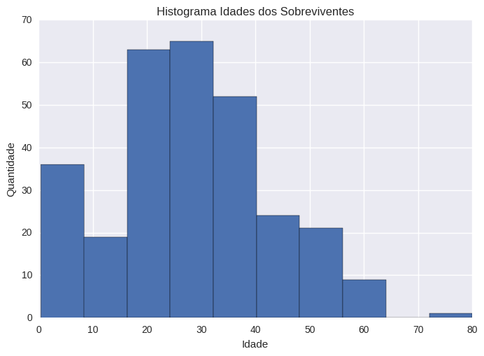

```python
survived['Age'].hist()
plt.title('Histograma Idades dos Sobreviventes')
plt.xlabel('Idade')
plt.ylabel('Quantidade')
```

Agora vou criar um para os falecidos, veja só:

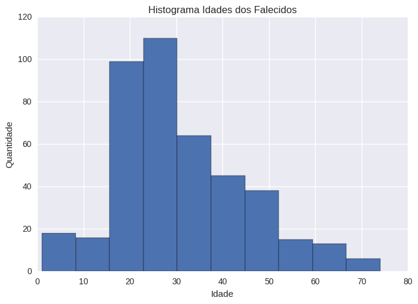

```python
killed['Age'].hist()
plt.title('Histograma Idades dos Falecidos')
plt.xlabel('Idade')
plt.ylabel('Quantidade')
```

Bom, podemos ver que existe uma diferença na distribuição das idades, certo? Mas acho que ficaria muito melhor analisarmos isso em um único gráfico. Você não concorda?

Veja só como fica:

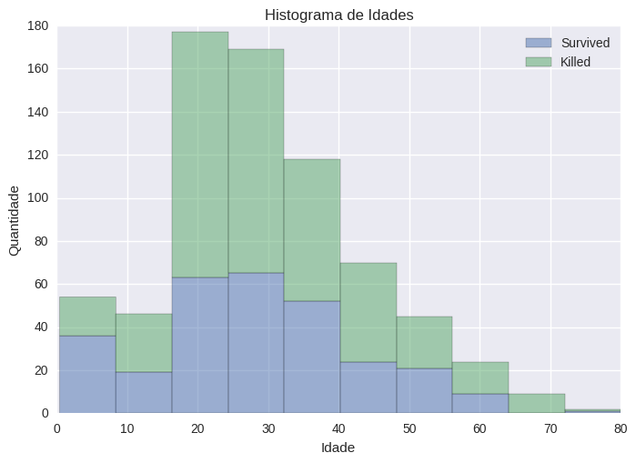

```python
### Aqui estou definindo as idades como sendo um do meu DF de sobreviventes e outro dos falecidos
all_ages = pd.DataFrame({'Survived': survived['Age'], 'Killed': killed['Age']}, columns=['Survived', 'Killed'])

all_ages.plot(kind='hist', alpha=0.5, stacked='true')
plt.title('Histograma de Idades')
plt.xlabel('Idade')
plt.ylabel('Quantidade')
```

Quais conclusões podemos tirar analisando esse gráfico?

Proporcionalmente apenas as pessoas com menos de 10 anos sobreviveram mais do que morreram. Pessoas acima de 65 anos não tiveram muita chance de sobreviver e acabaram falecendo. Acredito que isso deve-se ao fato de que os idosos já não possuem a mesma resistência do seu corpo :(

Os maiores níveis de mortalidade estão dentro da faixa de 20 - 40 anos.

Vamos analisar agora a idade combinada com o sexo da pessoa :)

obs: lembra quando eu disse lá no início que iria descartar valores nulos para realizar determinadas análises? Então, para realizar essa eu vou desconsiderar :)

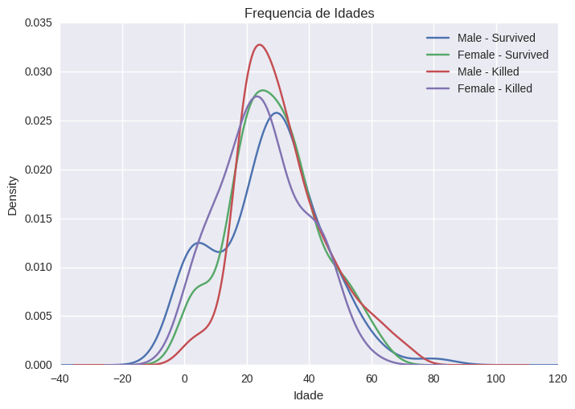

```python
# all_ages = pd.DataFrame({'Male - Survived': survived[survived['Sex'] == 'male']['Age'], 'Female - Survived': survived[survived['Sex'] == 'female']['Age'], 'Killed - Male': killed[killed['Sex'] == 'male']['Age'], 'Killed - Female': killed[killed['Sex'] == 'female']['Age']}, columns=['Survived - Male', 'Survived - Female', 'Killed - Male', 'Killed - Female'])

survived_male = survived[survived['Sex'] == 'male']['Age'].dropna()
survived_female = survived[survived['Sex'] == 'female']['Age'].dropna()
killed_male = killed[killed['Sex'] == 'male']['Age'].dropna()
killed_female = killed[killed['Sex'] == 'female']['Age'].dropna()

all_ages = pd.DataFrame({'Male - Survived': survived_male, 'Female - Survived': survived_female,
                        'Male - Killed': killed_male, 'Female - Killed': killed_female},
                        columns=['Male - Survived', 'Female - Survived', 'Male - Killed', 'Female - Killed'])

all_ages.plot(kind='kde', title='Frequencia de Idades')
plt.xlabel('Idade')
```

Hmmmmm... pra mim ficou um pouco confuso, o que você acha de separarmos em dois gráficos?

Veja só a minha sugestão:

Primeiro um gráfico analisando os sobreviventes

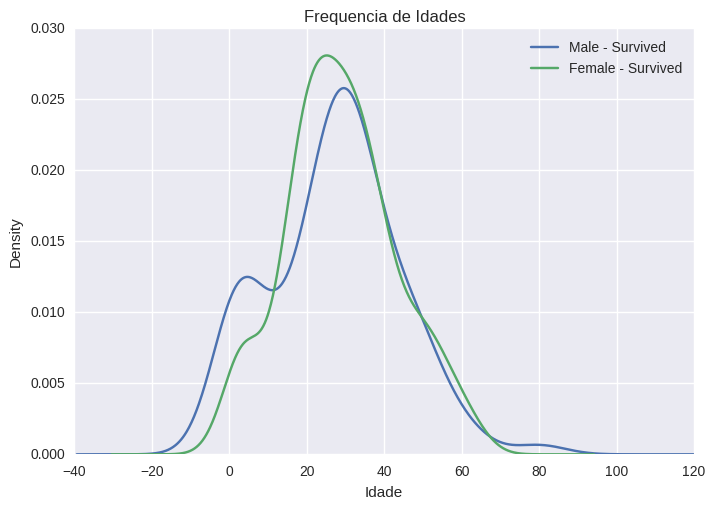

```python
all_ages = pd.DataFrame({'Male - Survived': survived_male, 'Female - Survived': survived_female},
                        columns=['Male - Survived', 'Female - Survived'])

all_ages.plot(kind='kde', title='Frequencia de Idades')
plt.xlabel('Idade')
```

Aqui podemos ver que ambos os picos estão próximos à 20 anos, porém existem também dois outros picos, bem suaves, perto de 1 ano. Será que significa que as mães salvaram também seus filhos? Acredito que sim :)

Vamos ver agora como fica essa distribuição quando analisada com os dados dos falecidos

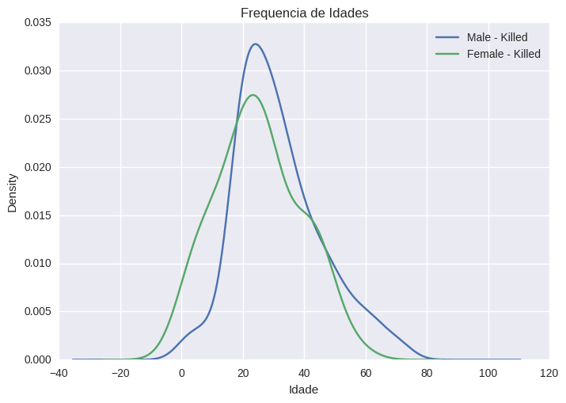

```python
all_ages = pd.DataFrame({'Male - Killed': killed_male, 'Female - Killed': killed_female},
                        columns=['Male - Killed', 'Female - Killed'])

all_ages.plot(kind='kde', title='Frequencia de Idades')
plt.xlabel('Idade')
```

Podemos ver que a grande parte dos homens que faleceram tinham idade próxima a 20 anos, porém ambas as distribuições são bem parecidas :)

Sendo assim já conseguimos responder a nossa pergunta: *Será que a idade também foi um fator importante nisso?*

### Dando continuidade à análise acima, vamos ainda ver mais gráficos sobre o sexo das pessoas

Como comentei no início, agora iremos ver se o sexo do tripulante foi um fator que alterou ou não a sua chance de sobreviver ao naufrágio!

Que tal começarmos analisando a proporção de homens e mulheres que embarcaram no navio? O que precisamos para fazer isso é realizar uma contagem agrupando pelo sexo. Para a nossa sorte já existe a função *groupby* escrita no Pandas, assim fica bem simples. Dê uma olhada :D

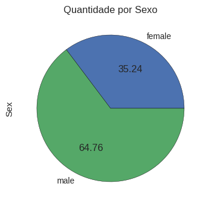

```python
pie_plot = pd.Series(titanic_data['Sex'].groupby(titanic_data['Sex']).count())

pie_plot.plot(kind='pie', figsize=(4,4), autopct='%.2f', title='Quantidade por Sexo')
```

Assim podemos ver que aprox. 2/3 da tripulação era do sexo masculino. Quando você precisa comparar a quantidade entre determinadas categorias a melhor forma de visualizar isso é através de um gráfico de pizza. Mas lembre-se, ele só é bom até uma certa quantidade de quebras, acredito que no máximo 4. Após isso já fica difícil de visualizar, aí já acredito que seja melhor utilizar um *Tree-map*. :)

### Vamos fazer a mesma comparação, porém com os sobreviventes e depois com os falecidos!

Realizei o mesmo código mostrado acima, porém troquei para utilizar o DataFrame *survived*

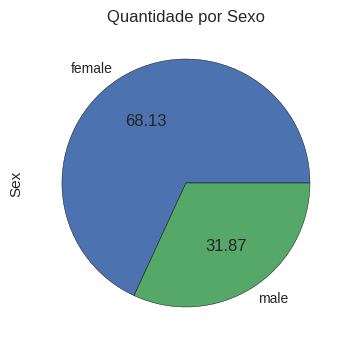

```python
pie_plot = pd.Series(survived['Sex'].groupby(survived['Sex']).count())

pie_plot.plot(kind='pie', figsize=(4,4), autopct='%.2f', title='Quantidade por Sexo')
```

Bom, aqui já podemos ver que mesmo a grande maioria da tripulação sendo masculina, foram as mulheres que mais sobreviveram, cerca também de 2/3 dos sobreveviventes eram mulheres :)

Realizando a mesma análise com o conjunto de dados dos falecidos temos:

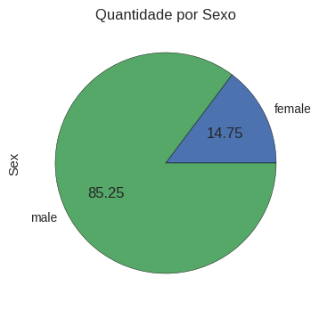

```python
pie_plot = pd.Series(killed['Sex'].groupby(killed['Sex']).count())

pie_plot.plot(kind='pie', figsize=(4,4), autopct='%.2f', title='Quantidade por Sexo')
```

Agora podemos ter certeza absoluta de que os homens sobreviveram muito menos do que as mulheres.

Não sabemos o real motivo que causou isso e também não podemos dizer com certeza que o **sexo** foi algo que incluenciou diretamente. Digo isso pois com certeza lá no início quando comentei que iríamos ver isso, você deve ter pensado que os *homens* teriam sobrevivido em maior número.. porém, como vimos, não foi o que aconteceu

# ANALISANDO AS TAXAS

Vamos ver aqui se o valor da passagem foi algo que ajudou ou não o passageiro à sobreviver. Por quê iremos ver isso? Imagino que se a pessoa compra uma passagem mais cara ela com certeza ficará em lugares "privilegiados", você não concorda?

Para começar irei criar um gráfico de densidade para vermos qual foi o range de valores que concentrou o maior número de passagens, tanto com os sobreviventes quando os falecidos!

Primeiro vamos ver como estão distribuídos estatisticamente os dados dessa coluna :)

```python
titanic_data['Fare'].describe()
```

```
count    891.000000
mean      32.204208
std       49.693429
min        0.000000
25%        7.910400
50%       14.454200
75%       31.000000
max      512.329200
Name: Fare, dtype: float64
```

```python
survived['Fare'].describe()
```

```
count    342.000000
mean      48.395408
std       66.596998
min        0.000000
25%       12.475000
50%       26.000000
75%       57.000000
max      512.329200
Name: Fare, dtype: float64
```

```python
killed['Fare'].describe()
```

```
count    549.000000
mean      22.117887
std       31.388207
min        0.000000
25%        7.854200
50%       10.500000
75%       26.000000
max      263.000000
Name: Fare, dtype: float64
```

Bom, olhando e interpretando apenas essas informações, já conseguimos ver que as pessoas que faleceram foram as que compraram as passagens com valores mais acessíveis.

Vamos ver como isso é distribuído no gráfico :)

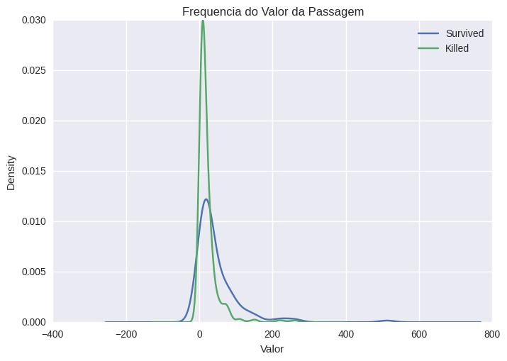

```python
series = pd.DataFrame({'Survived': survived['Fare'], 'Killed': killed['Fare']}, columns=['Survived', 'Killed'])

series.plot(kind='kde', title='Frequencia do Valor da Passagem')
plt.xlabel('Valor')
```

Bom, de cara conseguimos ver que a grande maioria das pessoas que faleceram foram as que pagaram um valor menor em suas passagens. Como a diferença é realmente grande para com os sobreviventes, eu acredito que isso foi algo que influenciou sim na sobrevivência do passageiro :)

### Vimos lá em cima que a coluna Pclass representa o classe econômica do passageiro. Vamos ver se isso foi um fator importante na sobrevivência.

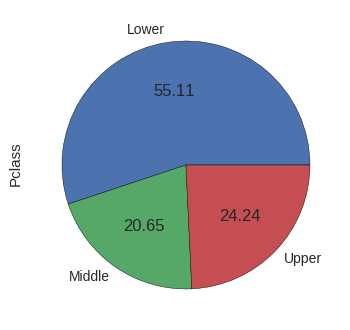

```python
### Lembrando que: 1 = Upper; 2 = Middle; 3 = Lower
pie_plot = pd.Series(titanic_data['Pclass'].groupby(titanic_data['Pclass']).count())

pie_plot.plot(kind='pie', figsize=(4,4), autopct='%.2f')
```

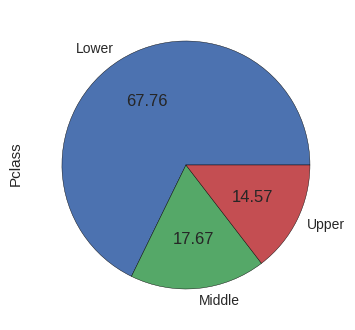

```python
### Lembrando que: 1 = Upper; 2 = Middle; 3 = Lower
pie_plot = pd.Series(killed['Pclass'].groupby(killed['Pclass']).count())

pie_plot.plot(kind='pie', figsize=(4,4), autopct='%.2f')
```

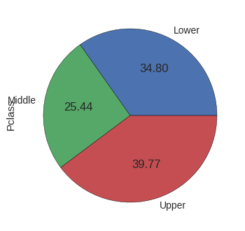

```python
### Lembrando que: 1 = Upper; 2 = Middle; 3 = Lower
pie_plot = pd.Series(survived['Pclass'].groupby(survived['Pclass']).count())

pie_plot.plot(kind='pie', figsize=(4,4), autopct='%.2f')
```

Com isso já conseguimos responder outra pergunta mencionada no início do documento :) Até agora já temos três perguntas que foram formuladas inicialmente respondidas, espero que você esteja gostando tanto quanto eu \o/

## Vamos ver agora se o setor da acomodação do passageiro foi algo determinante

Utilizando o *.head()*, vimos que a coluna *Cabin* é do tipo *C123*, ou seja, uma letra seguida por números. Aqui irei selecionar apenas a letra e iremos ver se isso foi algo que influenciou :)

```python
titanic_data['NewCabin'] = titanic_data['Cabin'].str[:1]
```

```python
survived['NewCabin'] = survived['Cabin'].str[:1]

killed['NewCabin'] = killed['Cabin'].str[:1]
```

```python
titanic_data.head()
```

|  | PassengerId | Survived | Pclass | Sex | Age | SibSp | Parch | Ticket | Fare | Cabin | Embarked | FirstName | LastName | NewCabin |
| --- | --- | --- | --- | --- | --- | --- | --- | --- | --- | --- | --- | --- | --- | --- |
| 0 | 1 | 0 | Lower | male | 22 | 1 | 0 | A/5 21171 | 7.2500 | NaN | S | Mr. Owen Harris | Braund | NaN |
| 1 | 2 | 1 | Upper | female | 38 | 1 | 0 | PC 17599 | 71.2833 | C85 | C | Mrs. John Bradley (Florence Briggs Thayer) | Cumings | C |
| 2 | 3 | 1 | Lower | female | 26 | 0 | 0 | STON/O2. 3101282 | 7.9250 | NaN | S | Miss. Laina | Heikkinen | NaN |
| 3 | 4 | 1 | Upper | female | 35 | 1 | 0 | 113803 | 53.1000 | C123 | S | Mrs. Jacques Heath (Lily May Peel) | Futrelle | C |
| 4 | 5 | 0 | Lower | male | 35 | 0 | 0 | 373450 | 8.0500 | NaN | S | Mr. William Henry | Allen | NaN |

```python
killed.head()
```

|  | PassengerId | Survived | Pclass | Sex | Age | SibSp | Parch | Ticket | Fare | Cabin | Embarked | FirstName | LastName | NewCabin |
| --- | --- | --- | --- | --- | --- | --- | --- | --- | --- | --- | --- | --- | --- | --- |
| 0 | 1 | 0 | Lower | male | 22 | 1 | 0 | A/5 21171 | 7.2500 | NaN | S | Mr. Owen Harris | Braund | NaN |
| 4 | 5 | 0 | Lower | male | 35 | 0 | 0 | 373450 | 8.0500 | NaN | S | Mr. William Henry | Allen | NaN |
| 5 | 6 | 0 | Lower | male | NaN | 0 | 0 | 330877 | 8.4583 | NaN | Q | Mr. James | Moran | NaN |
| 6 | 7 | 0 | Upper | male | 54 | 0 | 0 | 17463 | 51.8625 | E46 | S | Mr. Timothy J | McCarthy | E |
| 7 | 8 | 0 | Lower | male | 2 | 3 | 1 | 349909 | 21.0750 | NaN | S | Master. Gosta Leonard | Palsson | NaN |

```python
survived.head()
```

|  | PassengerId | Survived | Pclass | Sex | Age | SibSp | Parch | Ticket | Fare | Cabin | Embarked | FirstName | LastName | NewCabin |
| --- | --- | --- | --- | --- | --- | --- | --- | --- | --- | --- | --- | --- | --- | --- |
| 1 | 2 | 1 | Upper | female | 38 | 1 | 0 | PC 17599 | 71.2833 | C85 | C | Mrs. John Bradley (Florence Briggs Thayer) | Cumings | C |
| 2 | 3 | 1 | Lower | female | 26 | 0 | 0 | STON/O2. 3101282 | 7.9250 | NaN | S | Miss. Laina | Heikkinen | NaN |
| 3 | 4 | 1 | Upper | female | 35 | 1 | 0 | 113803 | 53.1000 | C123 | S | Mrs. Jacques Heath (Lily May Peel) | Futrelle | C |
| 8 | 9 | 1 | Lower | female | 27 | 0 | 2 | 347742 | 11.1333 | NaN | S | Mrs. Oscar W (Elisabeth Vilhelmina Berg) | Johnson | NaN |
| 9 | 10 | 1 | Middle | female | 14 | 1 | 0 | 237736 | 30.0708 | NaN | C | Mrs. Nicholas (Adele Achem) | Nasser | NaN |

Vamos realizar a mesma análise, ou seja, iremos agrupar para vermos a quantidade em cada setor :)

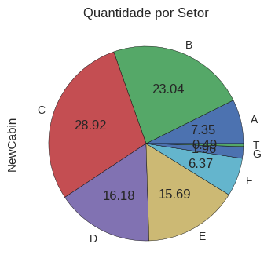

```python
pie_plot = pd.Series(titanic_data['NewCabin'].groupby(titanic_data['NewCabin']).count())

pie_plot.plot(kind='pie', figsize=(4,4), autopct='%.2f', title='Quantidade por Setor')
```

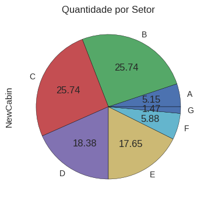

```python
pie_plot = pd.Series(survived['NewCabin'].groupby(survived['NewCabin']).count())

pie_plot.plot(kind='pie', figsize=(4,4), autopct='%.2f',  title='Quantidade por Setor')
```

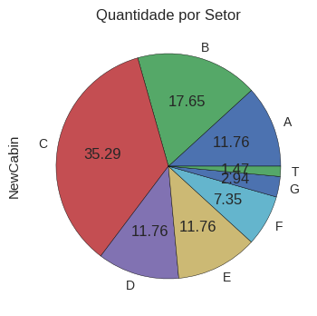

```python
pie_plot = pd.Series(killed['NewCabin'].groupby(killed['NewCabin']).count())

pie_plot.plot(kind='pie', figsize=(4,4), autopct='%.2f', title='Quantidade por Setor')
```

Bom, analisando o setor das cabines podemos ver que todos os tripulantes que estavam no setor *T* faleceram, mas nas outras não houve uma grande diferença também. Será que esse setor era um lugar "menos priveligiado"?

### Agora a única pergunta que falta respondermos é:

#### *Será que ter parentes influenciou na sobrevivência, no sentido de um "projeter" o outro?*

Vamos visualizar as primeiras linhas do dataset para vermos as colunas que iremos utilizar :)

```python
titanic_data.head()
```

|  | PassengerId | Survived | Pclass | Sex | Age | SibSp | Parch | Ticket | Fare | Cabin | Embarked | FirstName | LastName | NewCabin |
| --- | --- | --- | --- | --- | --- | --- | --- | --- | --- | --- | --- | --- | --- | --- |
| 0 | 1 | 0 | Lower | male | 22 | 1 | 0 | A/5 21171 | 7.2500 | NaN | S | Mr. Owen Harris | Braund | NaN |
| 1 | 2 | 1 | Upper | female | 38 | 1 | 0 | PC 17599 | 71.2833 | C85 | C | Mrs. John Bradley (Florence Briggs Thayer) | Cumings | C |
| 2 | 3 | 1 | Lower | female | 26 | 0 | 0 | STON/O2. 3101282 | 7.9250 | NaN | S | Miss. Laina | Heikkinen | NaN |
| 3 | 4 | 1 | Upper | female | 35 | 1 | 0 | 113803 | 53.1000 | C123 | S | Mrs. Jacques Heath (Lily May Peel) | Futrelle | C |
| 4 | 5 | 0 | Lower | male | 35 | 0 | 0 | 373450 | 8.0500 | NaN | S | Mr. William Henry | Allen | NaN |

Primeiramente irei executar o *.describe()* para ver, estatisticamente, como os valores dessa coluna estão distribuídos. Irei fazer isso nos nossos 3 DataFrames.

```python
titanic_data['SibSp'].describe()
```

```
count    891.000000
mean       0.523008
std        1.102743
min        0.000000
25%        0.000000
50%        0.000000
75%        1.000000
max        8.000000
Name: SibSp, dtype: float64
```

```python
survived['SibSp'].describe()
```

```
count    342.000000
mean       0.473684
std        0.708688
min        0.000000
25%        0.000000
50%        0.000000
75%        1.000000
max        4.000000
Name: SibSp, dtype: float64
```

```python
killed['SibSp'].describe()
```

```
count    549.000000
mean       0.553734
std        1.288399
min        0.000000
25%        0.000000
50%        0.000000
75%        1.000000
max        8.000000
Name: SibSp, dtype: float64
```

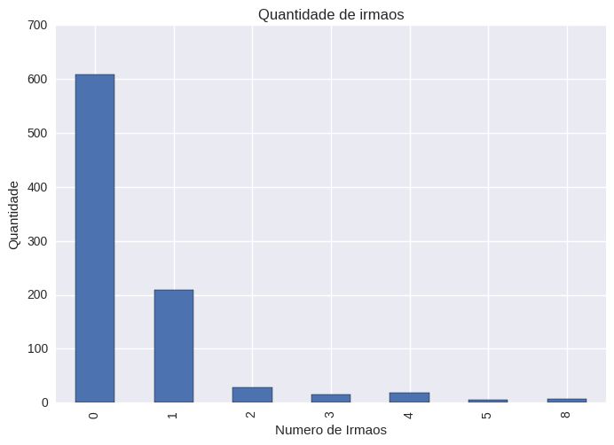

```python
bar_plot = pd.Series(titanic_data['SibSp'].groupby(titanic_data['SibSp']).count())

bar_plot.plot(kind='bar')
plt.title('Quantidade de irmaos')
plt.xlabel('Numero de Irmaos')
plt.ylabel('Quantidade')
```

Criei esse gráfico para vermos a quantidade de passageiros que estavam com irmãos. Vamos ver agora o mesmo gráfico, porém quebrado pela coluna **Survived**.

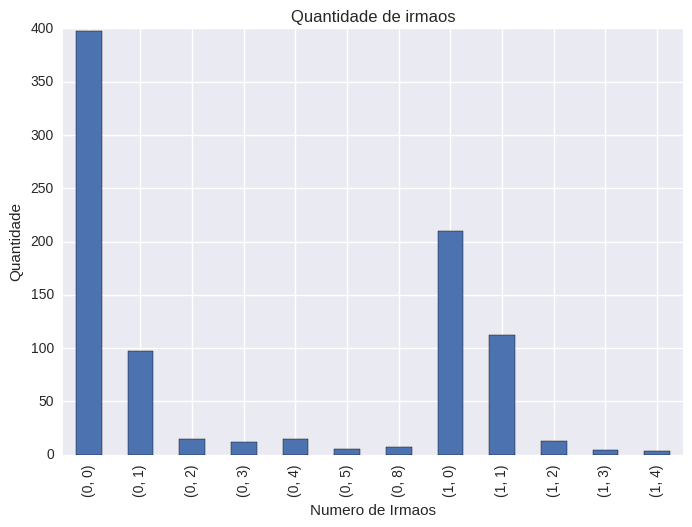

```python
bar_plot = pd.Series(titanic_data.groupby(['Survived','SibSp'])['Survived'].count())

bar_plot.plot(kind='bar', stacked=True)
plt.title('Quantidade de irmaos')
plt.xlabel('Numero de Irmaos')
plt.ylabel('Quantidade')
```

Bom, caso você não tenha entendido perfeitamente como ler a legenda do gráfico eu vou explicar. Por exemplo, (0,0) significa: O primeiro valor corresponde à variável de sobrevivência e o segundo ao número de irmãos. Ou seja, o par (0,0) representa as pessoas que faleceram que não tinham nenhum irmão.

De cara já podemos ver que as pessoas que tinham 5 ou mais irmãos não sobreviveram. Por que será? Acho que eles ficaram tentando salvar um ao outro e acabaram não conseguindo :(

Agora só falta realizarmos a mesma análise na coluna **Parch**.

```python
titanic_data['Parch'].describe()
```

```
count    891.000000
mean       0.381594
std        0.806057
min        0.000000
25%        0.000000
50%        0.000000
75%        0.000000
max        6.000000
Name: Parch, dtype: float64
```

```python
survived['Parch'].describe()
```

```
count    342.000000
mean       0.464912
std        0.771712
min        0.000000
25%        0.000000
50%        0.000000
75%        1.000000
max        5.000000
Name: Parch, dtype: float64
```

```python
killed['Parch'].describe()
```

```
count    549.000000
mean       0.329690
std        0.823166
min        0.000000
25%        0.000000
50%        0.000000
75%        0.000000
max        6.000000
Name: Parch, dtype: float64
```

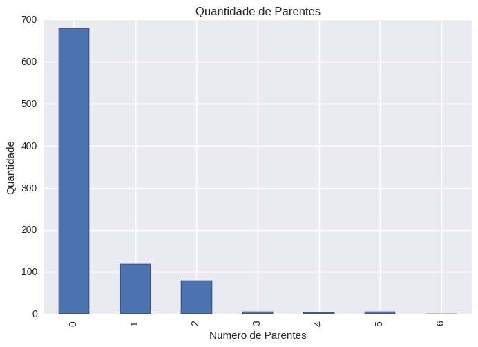

```python
bar_plot = pd.Series(titanic_data['Parch'].groupby(titanic_data['Parch']).count())

bar_plot.plot(kind='bar')
plt.title('Quantidade de Parentes')
plt.xlabel('Numero de Parentes')
plt.ylabel('Quantidade')
```

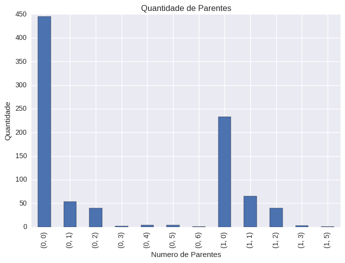

```python
bar_plot = pd.Series(titanic_data.groupby(['Survived','Parch'])['Survived'].count())

bar_plot.plot(kind='bar', stacked=True)
plt.title('Quantidade de Parentes')
plt.xlabel('Numero de Parentes')
plt.ylabel('Quantidade')
```

Aqui também ficou bem claro que pessoas com 4 ou 6 parentes faleceram. Novamente não sabemos o motivo ao certo, porém acredito que tenha acontecido o mesmo que foi mencionado acima :(

# Concluindo...

# 1 Será que a classe alterou significativamente a chance da pessoa sobreviver?

# 2 Será que a idade também foi um fator importante nisso?

# 3 Será que ter parentes influenciou na sobrevivência, no sentido de um "projeter" o outro?

# 4 Será que o setor que o tripulante estava colaborou com isso?

Com certeza existem variáveis ocultas que não estão em nosso conjunto de dados, porém conseguimos fazer uma análise completa, passando por praticamente todas as variáveis do nosso dataset :)

Acredito que, dado um conjunto de dados, podemos utilizar a nossa amostra para tomar como base e dizer se o tripulante "x" sobreviveria ou não ao naufrágio. Acredito que esse seria um ótimo trabalho para ser feito futuramente!

Até hoje o essa tragédia do Titanic é considerada a maior de todos os tempos envolvendo um navio. Muitos dizem que, quando um dos engenheiros do projeto foi questionado sobre a segurança do navio, ele respondeu: "O titanic é tão seguro que nem Deus conseguirá afundá-lo". Infelizmente isso aconteceu em sua primeira viagem :/

Um ponto importante a ser mencionando é que as análises aqui feitas são apenas uma formulação teórica com base em nossos dados, não existe nada que comprove as conclusões estatisticamente. O que também poderia ser um bom trabalho para estudos futuros :)

Para finalizar a análise, deixo abaixo a seguinte manchete do jornal *New York American* sobre o naufrágio

[figure not shown]